# Collecting web data with R

Worksheet

Ivo Bantel

2021-03-04

# Exercise 1

To practice scraping static pages, we start by simply reading data from the internet R. Suppose we want to scrape a website of quotes (http://quotes.toscrape.com/. Let’s just have a look at the webpage *using R*.

Load the package we’ll use for most scraping exercises - *rvest*.

```r
library(rvest)
```

Now, we want to read the page into R. Create a character vector `url_quotes` which contains the URL. Then, can check if this worked by calling the function `browseURL()` on `url_quotes`.

```r
url_quotes <- "http://quotes.toscrape.com"

# browseURL(url_quotes)
```

We now start by parsing the webpage (i.e. reading it into `R`). For this, pass `url_quotes` to the function `read_html()`.

```r
page_quotes <- read_html(url_quotes) # page_quotes now contains the entire page, including HTML commands
```

## Extracting elements

`read_html()` gives us the entire document including the HTML commands. Since we’re normally not interested in the formatting, use `html_text()` to extract only the Webpage text.

```r
page_quotes %>% html_text() # removes tags and formatting
```

```
## [1] "Quotes to Scrape\n    \n        \n            \n                \n                    Quotes to Scrape\n                \n            \n            \n                \n                \n                    Login\n                \n                \n            \n        \n    \n\n\n    \n\n …
```

Were you able to find the quotes? Let’s at least clean this up a little bit. Pass the output you produced above to `str_squish()` from the `stringr` package to remove repeated white space.

```r
page_quotes %>% html_text() %>% stringr::str_squish() # removes repeated whitespace
```

```
## [1] "Quotes to Scrape Quotes to Scrape Login “The world as we have created it is a process of our thinking. It cannot be changed without changing our thinking.” by Albert Einstein (about) Tags: change deep-thoughts thinking world “It is our choices, Harry, that show what we truly are, far more th…
```

That’s better - but it still looks very messy. If only there were a way to tell R to just fetch the quotes’ text! Lucky us: there is one! For this, we’ll need the CSS Selectors we talked about earlier.

### CSS Selectors

With `html_nodes()`, we can select specific elements of the HTML code (nodes). Familiarize yourself with the function by taking a look at the documentation of `html_nodes()`.

```r
#?html_nodes
```

Selectors work on HTML tags - in other words, we can use selectors to select HTML tags: write the name of a tag (without the brackets, and the CSS selector will select all elements with that tag

Let’s first try to select some elements. First select **headings** from the page using `html_nodes()`, then try the same for **links**.

```r
page_quotes %>% html_nodes("a") # "a", "h1"
```

```
## {xml_nodeset (55)}
##  [1] <a href="/" style="text-decoration: none">Quotes to Scrape</a>
##  [2] <a href="/login">Login</a>
##  [3] <a href="/author/Albert-Einstein">(about)</a>
##  [4] <a class="tag" href="/tag/change/page/1/">change</a>
##  [5] <a class="tag" href="/tag/deep-thoughts/page/1/">deep-thoughts</a>
##  [6] <a class="tag" href="/tag/thinking/page/1/">thinking</a>
##  [7] <a class="tag" href="/tag/world/page/1/">world</a>
##  [8] <a href="/author/J-K-Rowling">(about)</a>
##  [9] <a class="tag" href="/tag/abilities/page/1/">abilities</a>
## [10] <a class="tag" href="/tag/choices/page/1/">choices</a>
## [11] <a href="/author/Albert-Einstein">(about)</a>
## [12] <a class="tag" href="/tag/inspirational/page/1/">inspirational</a>
## [13] <a class="tag" href="/tag/life/page/1/">life</a>
## [14] <a class="tag" href="/tag/live/page/1/">live</a>
## [15] <a class="tag" href="/tag/miracle/page/1/">miracle</a>
## [16] <a class="tag" href="/tag/miracles/page/1/">miracles</a>
## [17] <a href="/author/Jane-Austen">(about)</a>
## [18] <a class="tag" href="/tag/aliteracy/page/1/">aliteracy</a>
## [19] <a class="tag" href="/tag/books/page/1/">books</a>
## [20] <a class="tag" href="/tag/classic/page/1/">classic</a>
## ...
```

The **universal selector** (star symbol) is very helpful - it returns *all* tags in the page. Try it on `page_quotes`.

```r
page_quotes %>% html_nodes("*")
```

```
## {xml_nodeset (151)}
##  [1] <head>\n<meta http-equiv="Content-Type" content="text/html; charset=UTF- ...
##  [2] <meta http-equiv="Content-Type" content="text/html; charset=UTF-8">\n
##  [3] <meta charset="UTF-8">\n
##  [4] <title>Quotes to Scrape</title>\n
##  [5] <link rel="stylesheet" href="/static/bootstrap.min.css">\n
##  [6] <link rel="stylesheet" href="/static/main.css">
##  [7] <body>\n    <div class="container">\n        <div class="row header-box" ...
##  [8] <div class="container">\n        <div class="row header-box">\n          ...
##  [9] <div class="row header-box">\n            <div class="col-md-8">\n       ...
## [10] <div class="col-md-8">\n                <h1>\n                    <a hre ...
## [11] <h1>\n                    <a href="/" style="text-decoration: none">Quot ...
## [12] <a href="/" style="text-decoration: none">Quotes to Scrape</a>
## [13] <div class="col-md-4">\n                <p>\n                \n          ...
## [14] <p>\n                \n                    <a href="/login">Login</a>\n  ...
## [15] <a href="/login">Login</a>
## [16] <div class="row">\n    <div class="col-md-8">\n\n    <div class="quote"  ...
## [17] <div class="col-md-8">\n\n    <div class="quote" itemscope itemtype="htt ...
## [18] <div class="quote" itemscope itemtype="http://schema.org/CreativeWork">\ ...
## [19] <span class="text" itemprop="text">“The world as we have created it is a ...
## [20] <span>by <small class="author" itemprop="author">Albert Einstein</small> ...
## ...
```

As we will focus on gathering specific information, the universal selector is not our first tool of choice but it can come very handy sometimes.

For more complicated CSS selectors, we will use a tool that helps us determine the correct selectors: the [selector gadget](https://chrome.google.com/webstore/detail/selectorgadget/mhjhnkcfbdhnjickkkdbjoemdmbfginb). For a list of CSS Selectors, check out [this collection](https://www.w3schools.com/cssref/css_selectors.asp) - and if you want to practice CSS Selectors in a fun (and food-related) way, play with the [CSS Diner](https://flukeout.github.io) that helps you learn about different selector structures.

### Applying CSS Selectors

Let’s now try to apply this in a more useful way to the quotes we scraped. Parse the page as we did before. Then use the CSS selector and `html_nodes()` to select only the *author* elements (use the selector gadget to identify the relevant selector).

```r
"http://quotes.toscrape.com" %>% # read in page
  read_html() %>% # parse page
  html_nodes(".author") # get author elements
```

```
## {xml_nodeset (10)}
##  [1] <small class="author" itemprop="author">Albert Einstein</small>
##  [2] <small class="author" itemprop="author">J.K. Rowling</small>
##  [3] <small class="author" itemprop="author">Albert Einstein</small>
##  [4] <small class="author" itemprop="author">Jane Austen</small>
##  [5] <small class="author" itemprop="author">Marilyn Monroe</small>
##  [6] <small class="author" itemprop="author">Albert Einstein</small>
##  [7] <small class="author" itemprop="author">André Gide</small>
##  [8] <small class="author" itemprop="author">Thomas A. Edison</small>
##  [9] <small class="author" itemprop="author">Eleanor Roosevelt</small>
## [10] <small class="author" itemprop="author">Steve Martin</small>
```

Just selecting the nodes is helpful - but not quite what we want yet. Let’s get just the *author names* by using `html_text()`:

```r
"http://quotes.toscrape.com" %>% # read in page
  read_html() %>% # parse page
  html_nodes(".author") %>% # get author elements
  html_text() # extract text
```

```
##  [1] "Albert Einstein"   "J.K. Rowling"      "Albert Einstein"
##  [4] "Jane Austen"       "Marilyn Monroe"    "Albert Einstein"
##  [7] "André Gide"        "Thomas A. Edison"  "Eleanor Roosevelt"
## [10] "Steve Martin"
```

Now, do the same thing to get the quote texts.

```r
"http://quotes.toscrape.com" %>% # read in page
  read_html() %>% # parse page
  html_nodes(".quote") %>% # get quote elements
  html_text() %>% # get text of quotes
  stringr::str_squish() # clean up
```

```
##  [1] "“The world as we have created it is a process of our thinking. It cannot be changed without changing our thinking.” by Albert Einstein (about) Tags: change deep-thoughts thinking world"
##  [2] "“It is our choices, Harry, that show what we truly are, far more than our abilities.” by J.K. Rowling (about) Tags: abilities choices"
##  [3] "“There are only two ways to live your life. One is as though nothing is a miracle. The other is as though everything is a miracle.” by Albert Einstein (about) Tags: inspirational life live miracle miracles"
##  [4] "“The person, be it gentleman or lady, who has not pleasure in a good novel, must be intolerably stupid.” by Jane Austen (about) Tags: aliteracy books classic humor"
##  [5] "“Imperfection is beauty, madness is genius and it's better to be absolutely ridiculous than absolutely boring.” by Marilyn Monroe (about) Tags: be-yourself inspirational"
##  [6] "“Try not to become a man of success. Rather become a man of value.” by Albert Einstein (about) Tags: adulthood success value"
##  [7] "“It is better to be hated for what you are than to be loved for what you are not.” by André Gide (about) Tags: life love"
##  [8] "“I have not failed. I've just found 10,000 ways that won't work.” by Thomas A. Edison (about) Tags: edison failure inspirational paraphrased"
##  [9] "“A woman is like a tea bag; you never know how strong it is until it's in hot water.” by Eleanor Roosevelt (about) Tags: misattributed-eleanor-roosevelt"
## [10] "“A day without sunshine is like, you know, night.” by Steve Martin (about) Tags: humor obvious simile"
```

# Exercise 2

Exercise 2 contains less detailed instructions. If you’re unsure about how to proceed, you can either revisit the steps in Exercise 1, look at hints (where available), use your favourite search engine, or consult with the people in your breakout room.

## Warm-up: headings

We now practice grabbing CSS Selectors and apply our skills to a more political science-related, real life site: select article headings from the [homepage of the guardian](https://www.theguardian.com).

```r
url_guardian <- "https://www.theguardian.com" # read in url
page_guardian <- read_html(url_guardian) # parse page

selected_nodes_guardian <- page_guardian %>% html_nodes("h3") # select nodes

text <- selected_nodes_guardian %>% html_text() %>% # select html text
  stringr::str_squish() # remove empty white space
```

## Exercise: categories

Look at the selected nodes’ text (with white space removed). Then try to extract the categories which the guardian assigns (the bold red text on the page). If you get stuck, use the hints below.

**Click to read first hint**

To achieve this, try the CSS Selector Gadget and, if you cannot get this to work, your browser’s Developer Tools window (Firefox & Chrome: F12).

**Click to read second hint**

Use the Developer Tools window to find what class the elements have that you are trying to get.

**Click to read third hint**

You’re trying to get the elements of class `fc-item__kicker`. (Use `.fc-item__kicker`)

```r
categories <- page_guardian %>%
  html_nodes('.fc-item__kicker') %>% # select elements of <span class="fc-item__kicker">
  html_text() %>% # select text only
  table() # get overview of frequencies
```

# Exercise 3

Now, we will practice scraping tables. Out of the box, the `rvest` package is able to not only collect a table but also converts it into a list of data frames when we call `html_table()` on a page.

The most important specification is the `fill` parameter: `html_table(fill=TRUE)` tells `rvest` to automatically fill rows with fewer than the maximum number of columns with NAs. This is crucial, since tables in real life are often messy. This means, the number of cells per row is inconsistent or the format is irregular in another way. The fill specificaion will deal with that by adding NA values. In practice, you will only use `fill=FALSE` (the default) if you’re certain that the table is tidy.

Try it out on the *Timeline* table in the [wikipedia article on women’s suffrage](https://en.wikipedia.org/wiki/Women%27s_suffrage). Read the page and then apply the `html_table()` command with and without the specification.

```r
tables <- read_html("https://en.wikipedia.org/wiki/Women%27s_suffrage") %>% html_table()
```

```
## Error: Table has inconsistent number of columns. Do you want fill = TRUE?
```

```r
tables_filled <- read_html("https://en.wikipedia.org/wiki/Women%27s_suffrage") %>% html_table(fill=T)
```

The resulting object will be a list of tables (`data.frame`s). To extract the table we’re interested in (the “Timeline” table), we can use base notation (e.b. `[[1]]`) or, in a piping-chain, the command `extract2()` from the `magrittr` package, adding the number of the table in brackets (e.g. `extrac2(1)`; the command name is no typo - `extract` works for vectors, `extract2()` for lists).

**Using both variants, extract the Timeline table from the list of tables that we scraped and inspect the table in a bit more detail.**

```r
#tables_filled[[7]]

tables_filled %>% magrittr::extract2(7)
```

```
##                                                                                                                       Country
## 1                                                                                                                 Afghanistan
## 2                                                                                                                 Albania[40]
## 3                                                                                                                     Algeria
## 4                                                                                                                     Andorra
## 5                                                                                                                      Angola
## 6                                                                                                                   Argentina
## 7                                                                                                                     Armenia
## 8                                                                                                                   Australia
## 9                                                                                                                     Austria
## 10                                                                                                                 Azerbaijan
## 11                                                                                                                    Bahamas
## 12                                                                                                                    Bahrain
## 13                                                                                                                 Bangladesh
## 14                                                                                                                   Barbados
```

[output cut: 777 more lines]

As you can easily see, the table is too messy to use right away. In a real project, the task would now be to clean the table (e.g. using [`stringr`](https://evoldyn.gitlab.io/evomics-2018/ref-sheets/R_strings.pdf)). Gladly, we’ll be able to skip this here. ;)

Let’s at least do some minor cleaning to have something to visualize. First, transform the table to a dataframe.

```r
df <- tables_filled %>% magrittr::extract2(7) %>% data.frame()
```

Then (using `dplyr::mutate`), introduce a new column `Year` containing the year women were first granted suffrage at the national level, and drop all columns except `Country` and `Year` (using `dplyr::select`).

```r
df <- tables_filled %>% magrittr::extract2(7) %>%
  data.frame() %>%
  dplyr::mutate(Year = readr::parse_number(Year.women.first.granted.suffrage.at.national.level, na = "No voting")) %>%
  dplyr::select(-c(Notes, Year.women.first.granted.suffrage.at.national.level, NA.))
```

Now, inspect the data frame: what else would we need to clean?

```r
df
```

```
##                                                                                                                       Country
## 1                                                                                                                 Afghanistan
## 2                                                                                                                 Albania[40]
## 3                                                                                                                     Algeria
## 4                                                                                                                     Andorra
## 5                                                                                                                      Angola
## 6                                                                                                                   Argentina
## 7                                                                                                                     Armenia
## 8                                                                                                                   Australia
## 9                                                                                                                     Austria
## 10                                                                                                                 Azerbaijan
## 11                                                                                                                    Bahamas
## 12                                                                                                                    Bahrain
## 13                                                                                                                 Bangladesh
## 14                                                                                                                   Barbados
```

[output cut: 381 more lines]

Let’s remove the square brackets (and what they contain) as well as today’s description of the country.

**Click to read first hint**

Use the syntax `dplyr::mutate(Country = gsub("TO_BE_REPLACED", "", Country))`

**Click to read second hint**

For the regular expressions, use `"\\["` for the opening square bracket (equivalent for the regular brackets) and `".*?` for any number of characters in the brackets.

```r
df <- df %>% dplyr::mutate(Country = gsub("\\[.*?\\]", "", Country)) %>%
  dplyr::mutate(Country = gsub("\\(.*?\\)", "", Country))
```

Now, let’s find out how the introduction of women’s suffrage is distributed using a simple graph (create a simple table and call `plot()` on it), and which countries were first and last in the data set.

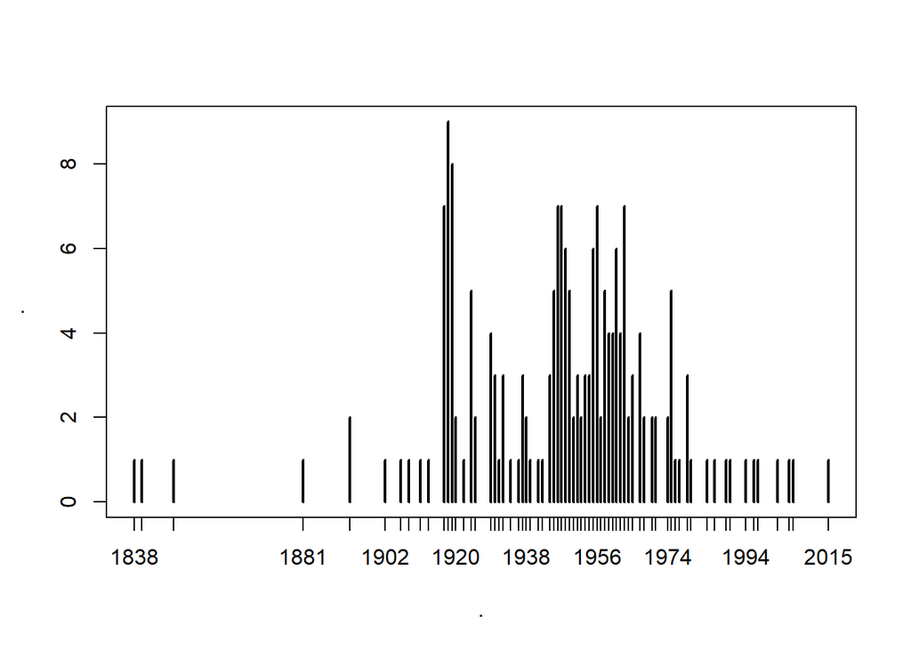

```r
df$Year %>% table() %>% plot() # plot
```

```r
df %>% dplyr::arrange(Year) %>% head(1) # select first country
```

```
##            Country Year
## 1 Pitcairn Islands 1838
```

```r
df %>% dplyr::arrange(desc(Year)) %>% head(1) # select last country
```

```
##        Country Year
## 1 Saudi Arabia 2015
```